# Prueba de una muestra con t de Student

### Comunicación de los resultados

**Escrito.** Como mínimo, se debe informar la estadística de prueba *t* observada, el valor de *p* y el número de grados de libertad. Por ejemplo, se podría escribir “La media del recuento de polen de las huellas (109) fue significativamente más baja de lo esperado si proviniera del bosque cercano con un recuento promedio de 125 (*t* = 3.07, df = 9, P = 0.01)”.

**Visual.** Los diagramas de caja o histogramas de frecuencia se pueden utilizar para visualizar la variación en una sola variable. En este ejemplo, se podría utilizar una línea o una flecha para indicar el valor único (125) con el que se estaba comparando la muestra.

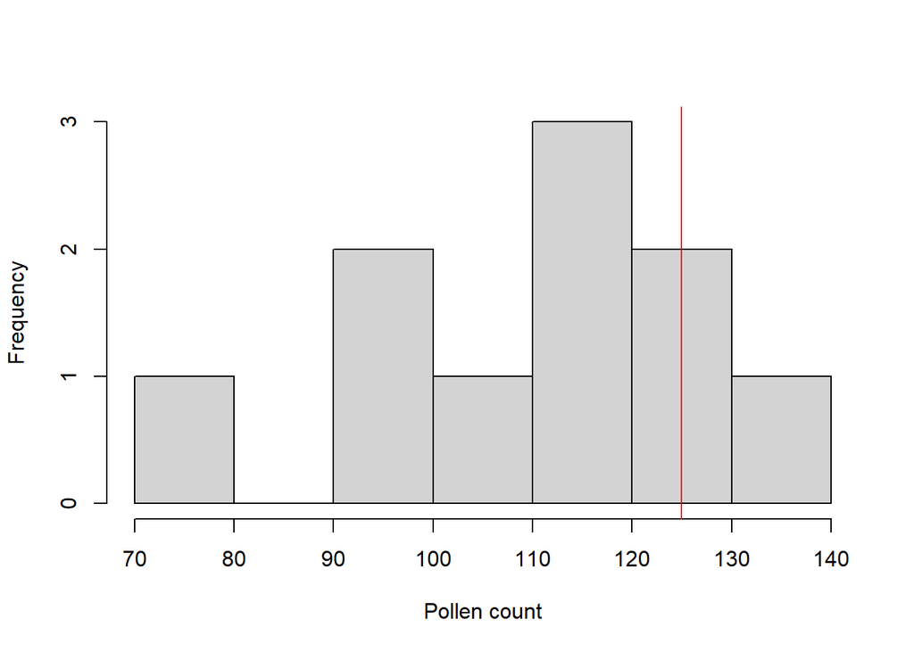

```r
hist(pollen, xlab = "Pollen count", main = NULL)
abline(v = 125, col = "red")
```

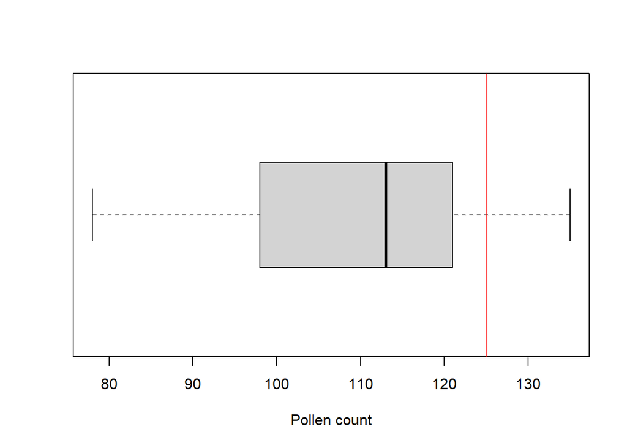

```r
boxplot(pollen, xlab = "Pollen count", horizontal = TRUE)
abline(v = 125, col = "red")
```

### Más ayuda

Escribe `?t.test` para obtener la ayuda de R sobre esta función.

Quinn and Keough (2002) **Experimental design and data analysis for biologists*. Cambridge University Press. Capítulo 3: Prueba de hipótesis.

McKillup (2012) *Statistics explained. An introductory guide for life scientists.* Cambridge University Press. Capítulo 9: Comparación de las medias de una y dos muestras de datos distribuidos normalmente.

**Autor**: Alistair Poore

**Año**: 2016

**Última actualización**: Jun. 2023